# Intro to classification - kNN - 3

One should look for what is and not what he thinks should be. (Albert Einstein)

# Field trip: Teachable Snake

- Classifying with kNN can seem really simple due to the fact that it just stores training data rather than actively performing calculations
- Despite its simplicity, it is often at the core of complex classification tasks
- On a **white sheet of paper** or an **index card, draw an arrow**
- Then, visit https://teachable-snake.netlify.app/ to play a quick game of **Teachable Snake**

# Teachable Snake debrief

- Believe it or not, kNN is at the core of Google Creative Lab’s Teachable Machine, a tool for creating ML models – learn more [here](https://teachablemachine.withgoogle.com/)
- Google’s boilerplate documentation, available via GitHub [here](https://github.com/googlecreativelab/teachable-machine-boilerplate), explains how to combine kNN with a neural network for image recognition
- Read more about Teachable Snake at the creator’s website by clicking [here](https://www.vinceshao.com/works/teachable-snake/)

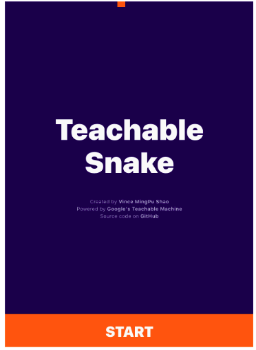

# Module completion checklist

| Objective | Complete |
| --- | --- |
| Identify performance metrics for classification algorithms and evaluate a simple kNN model |  |

# kNN: modeling with KNeighborsClassifier

- We will use the `sklearn.neighbors` function, `KNeighborsClassifier`
- We will be using mostly `sklearn` modules and functions for classification and machine learning

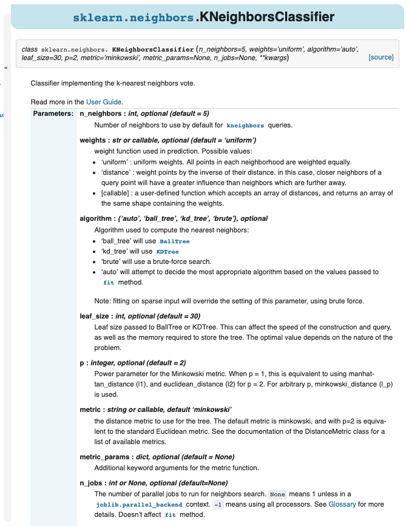

# kNN: build model

- We now will instantiate our kNN model and run it on `X_train`
- At first, we will simply run the model on our training data and predict on test
- We set `n_neighbors = 5` as a random guess; usually we can use 3 or 5
- We will use cross-validation to optimize our model next time
- Using this process, we will also choose the best `n_neighbors` for an optimal result

```python
# Create kNN classifier.
default = 5
kNN = KNeighborsClassifier(n_neighbors = default)
# Fit the classifier to the data.
kNN.fit(X_train, y_train)
```

```
KNeighborsClassifier()
```

**Note that we typically choose an odd number of nearest neighbors to ensure that there are no ‘ties’**

# kNN: predict on a test set

- Now we will take our trained model and predict on a test set

```python
predictions = kNN.predict(X_test)
```

- What we get is a vector of predicted values

```python
print(predictions[0:5])
```

```
[False False False False False]
```

# kNN: predict on test

- Let’s quickly glance at our first five **actual observations** vs our first five predicted observations
- This is helpful because we have the actual values for this sample

```python
actual_v_predicted = np.column_stack((y_test, predictions))
print(actual_v_predicted[0:5])
```

```
[[False False]
 [False False]
 [False False]
 [False False]
 [False False]]
```

# Module completion checklist

| Objective | Complete |
| --- | --- |
| Implement kNN algorithm on the training data without cross-validation | **✔** |
| Identify performance metrics for classification algorithms and evaluate a simple kNN model |  |

# Classification: assessing performance

- Our outcome variable is **binary**, and we need to understand how to measure error in classification problems
- The following terms are very important to measure performance of a classification algorithm
  - Confusion matrix
  - Accuracy
  - Receiver operating characteristic (ROC) curve
  - Area under the curve (AUC)

# Classification: sklearn.metrics

- `sklearn.metrics` has many packages that are used to calculate metrics for various models
- We will be using metrics found within the *Classification metrics* section
- Here is an idea of what we can calculate using this library

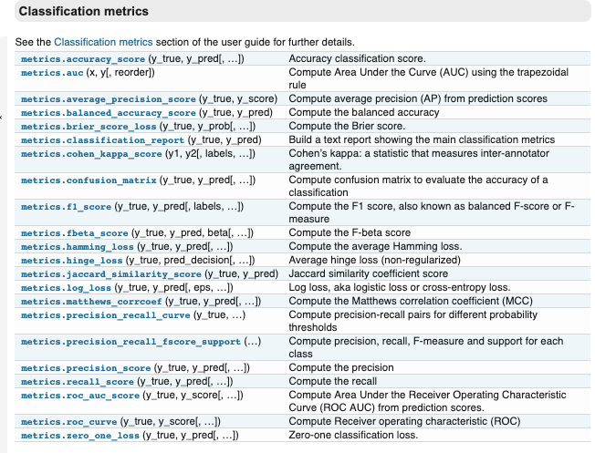

# Confusion matrix: what is it?

- A confusion matrix is what we use to measure error
- We use it to calculate Accuracy, Misclassification rate, True positive rate, False positive rate, and Specificity
- In the matrix overview of our data, let `Y1` be “non-vulnerable” and `Y2` be “vulnerable”

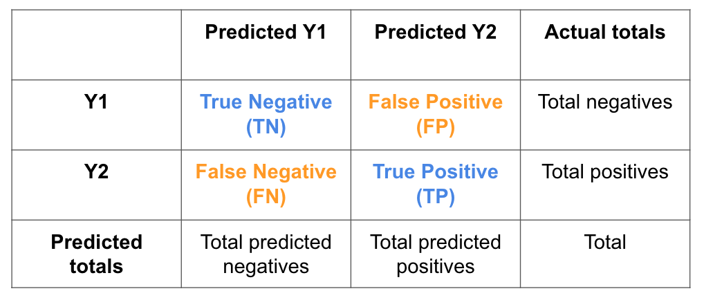

# Confusion matrix: accuracy

- We will now review the metrics we are looking for from the confusion matrix, one at a time

**Accuracy**: overall, how often is the classifier correct?

**TP + TN** / **total**

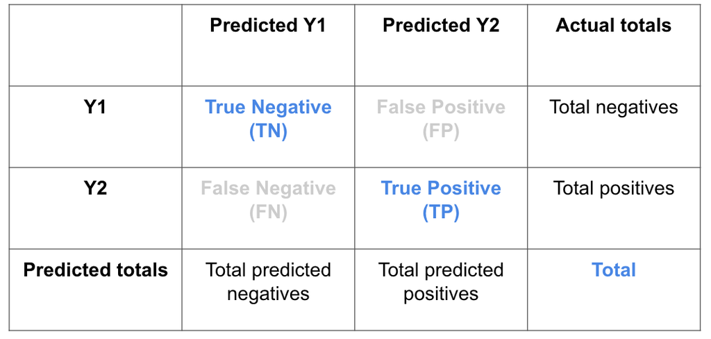

# Confusion matrix: misclassification rate

**Misclassification rate (error rate)**: overall, how often is the classifier wrong?

FP + FN / **total**

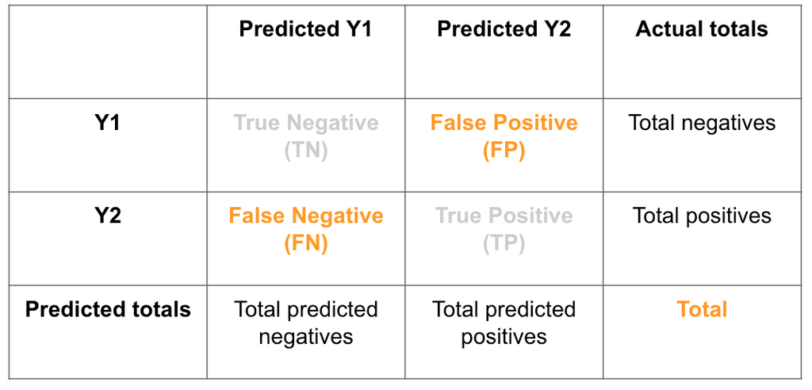

# Confusion matrix: true positive rate

**TP** / **actual yes**

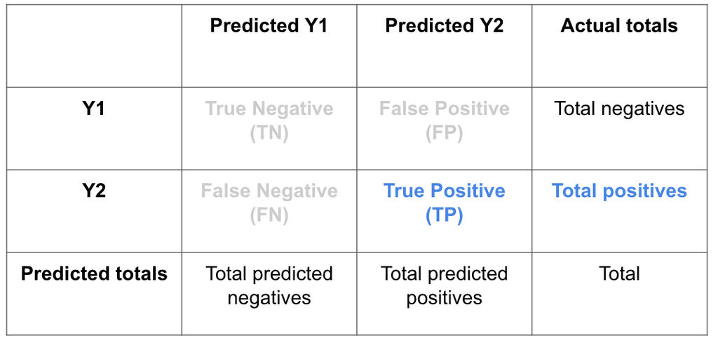

# Confusion matrix: false positive rate

**False positive rate**: when it’s actually no, how often does it predict yes?

FP / **actual no**

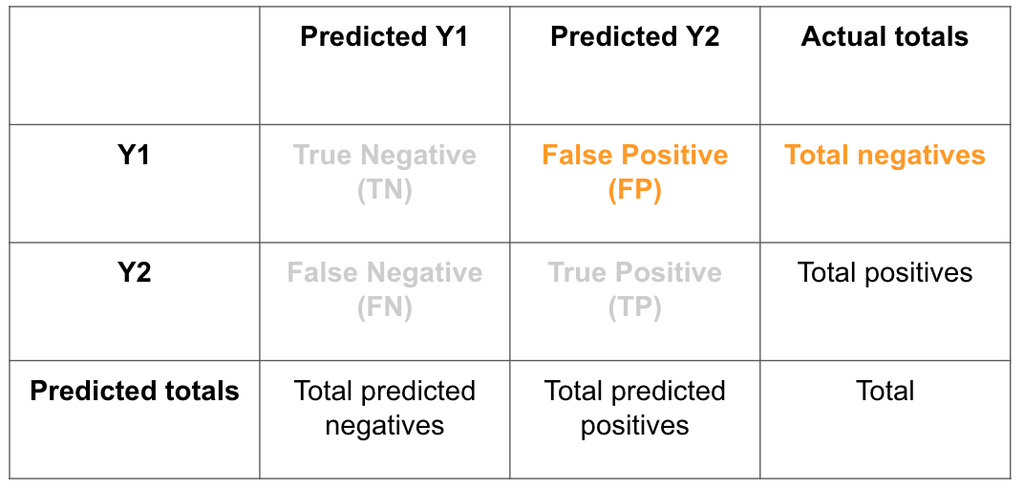

# Confusion matrix: specificity

**True Negative Rate (Specificity)**: when it’s actually no, how often does it predict no?

TN / **actual no**

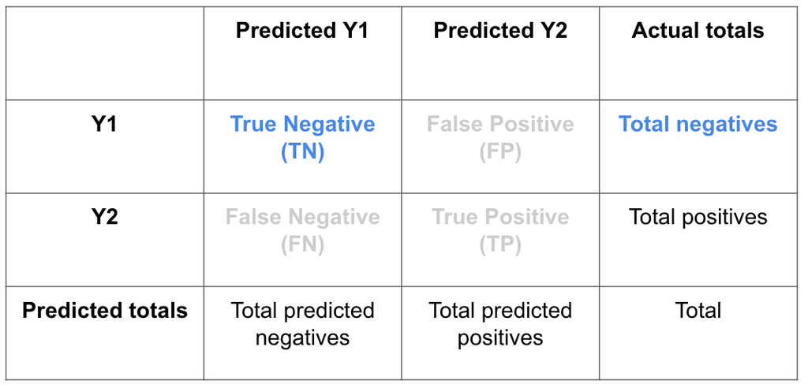

# Confusion matrix: summary

- Here is a table with all the metrics in one place:

| Metric name | Formula |
| --- | --- |
| Accuracy | True positive + True Negative / Overall total |
| Misclassification rate | False positive + False Negative / Overall total |
| True positive rate | True positive / Actual yes (True positive + False negative) |
| False positive rate | False positive / Actual no (False positive + True negative) |
| Specificity | True negative / Actual no (False positive + True negative) |

# Understanding medical tests: sensitivity, specificity, and positive predictive value

- A test that’s highly sensitive will flag almost everyone who has the disease and not generate many false-negative results. (Example: a test with 90% sensitivity will correctly return a positive result for 90% of people who have the disease, but will return a negative result — a false-negative — for 10% of the people who have the disease and should have tested positive.)
- A high-specificity test will correctly rule out almost everyone who doesn’t have the disease and won’t generate many false-positive results. (Example: a test with 90% specificity will correctly return a negative result for 90% of people who don’t have the disease, but will return a positive result — a false-positive — for 10% of the people who don’t have the disease and should have tested negative.)

# Understanding medical tests: Pregnancy test results

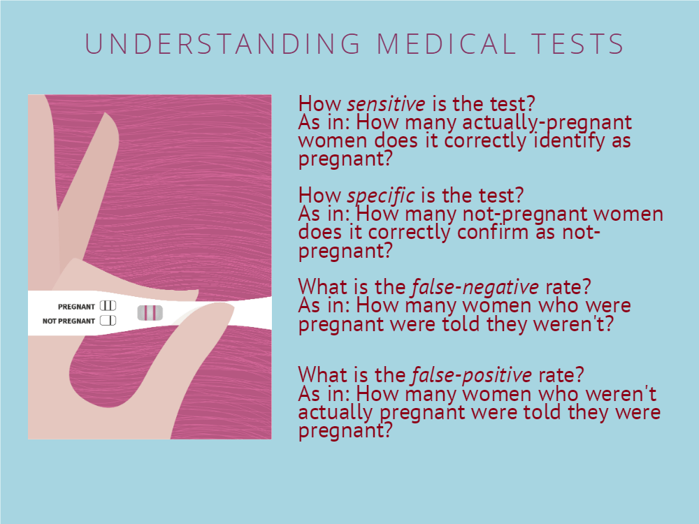

# Confusion matrix in python

- Now that we know the metrics behind the madness, let’s execute the code to build a confusion matrix in Python
- We use a function called `confusion_matrix` from `sklearn.metrics`

```python
# Confusion matrix for kNN.
cm_kNN = confusion_matrix(y_test, predictions)
print(cm_kNN)
```

```
[[1443    7]
 [  82    1]]
```

- We won’t go through all of the metrics right now, but let’s calculate accuracy because it’s a metric used frequently to compare classification models
- **Accuracy = True positive + True Negative / Overall total**
- Using `accuracy_score` from `sklearn.metrics`, we calculate:

```python
print(round(accuracy_score(y_test, predictions),
4))
```

```
0.9419
```

# Confusion matrix: visualize

- Let’s visualize our confusion matrix

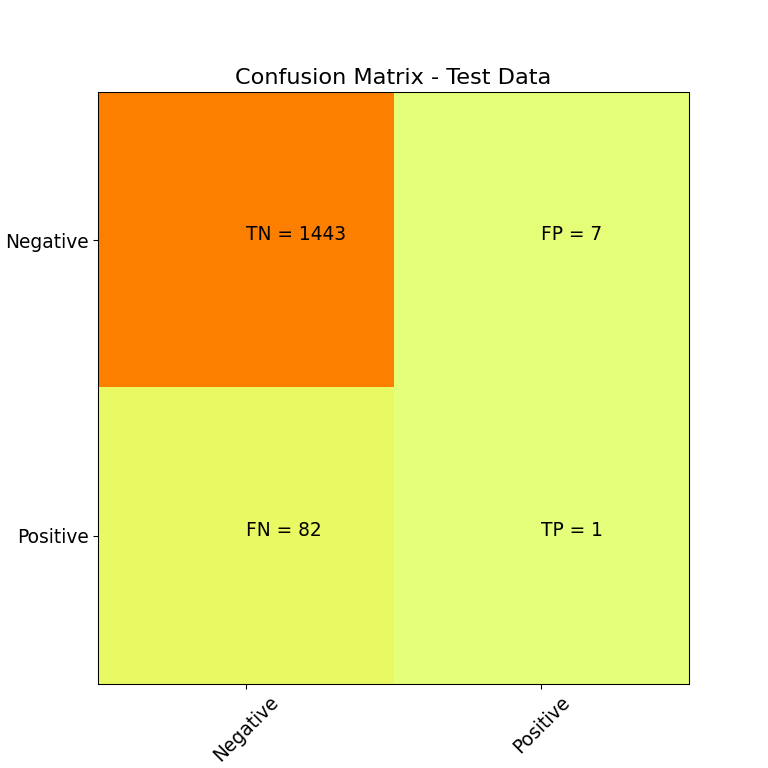

```python
plt.imshow(cm_kNN, interpolation = 'nearest', cmap = plt.cm.Wistia)
classNames = ['Negative', 'Positive']
plt.title('Confusion Matrix - Test Data')
plt.ylabel('True label')
plt.xlabel('Predicted label')
tick_marks = np.arange(len(classNames))
plt.xticks(tick_marks, classNames, rotation = 45)
plt.yticks(tick_marks, classNames)
s = [['TN', 'FP'], ['FN', 'TP']]
for i in range(2):
    for j in range(2):
        plt.text(j,i, str(s[i][j]) + " = " + str(cm_kNN[i][j]))
plt.show()
```

# Evaluation of kNN with k neighbors

- Let’s store the accuracy of this model. This way we can access it later to compare.

```python
# Create a dictionary with accuracy values for our kNN model with k.
model_final_dict = {'metrics': ["accuracy"],
                    'values':[round(accuracy_score(y_test, predictions), 4)],
                    'model':['kNN_k']}
model_final = pd.DataFrame(data = model_final_dict)
print(model_final)
```

```
    metrics  values  model
0  accuracy  0.9419  kNN_k
```

- Our model is not doing great, but we will now observe how it does compared to other models.

# Performance of our kNN model

- The remaining metrics we want to look at to evaluate our model are:
  - Receiver operating characteristic (ROC) curve
  - Area under the curve (**AUC**)

[figure not shown]

# ROC: receiver operator characteristic

- ROC is a plot of the true positive rate (**TPR**) against the false positive rate (FPR)
- The plot illustrates the trade off between the TPR and FPR
- Classification models produce them to show the performance of the model and allow us to choose which threshold to use

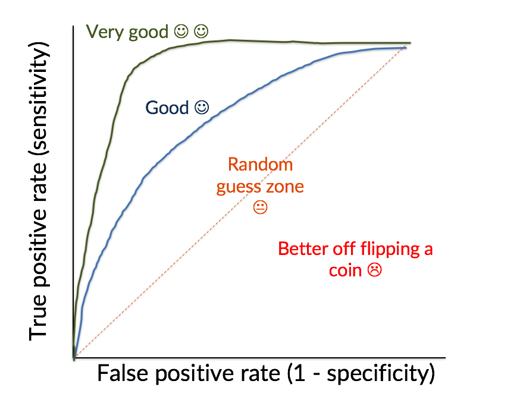

# AUC: area under the curve

- The AUC is a **performance metric** used to compare classification models to measure predictive accuracy
- The AUC should be **above .5** to say the model is better than a random guess
- The perfect AUC `= 1` (you will never see this number working with real world data!)

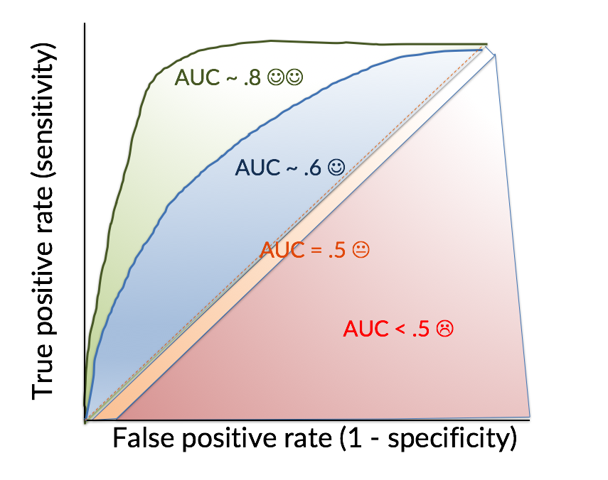

# Plot ROC and calculate AUC

- Let’s plot the ROC for our model and calculate the **AUC**

```python
# Store FPR, TPR, and threshold as variables.
fpr, tpr, threshold = metrics.roc_curve(y_test, predictions)
# Store the AUC.
roc_auc = metrics.auc(fpr, tpr)
```

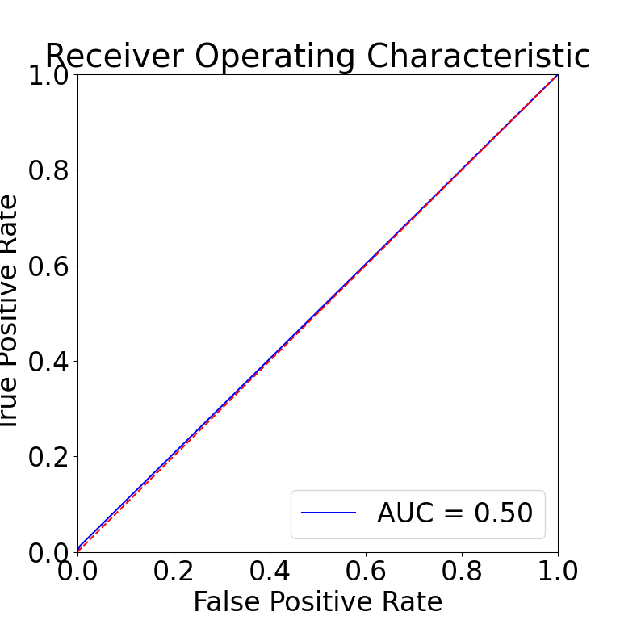

```python
plt.title('Receiver Operating Characteristic')
plt.plot(fpr, tpr, 'b', label = 'AUC = %0.2f' % roc_auc)
plt.legend(loc = 'lower right')
plt.plot([0, 1], [0, 1],'r--')
plt.xlim([0, 1])
plt.ylim([0, 1])
plt.ylabel('True Positive Rate')
plt.xlabel('False Positive Rate')
plt.show()
```

# Knowledge check

[figure not shown]

# Module completion checklist

| Objective | Complete |
| --- | --- |
| Implement kNN algorithm on the training data without cross-validation | **✔** |
| Identify performance metrics for classification algorithms and evaluate a simple kNN model | **✔** |

# Congratulations on completing this module!

You are now ready to try Tasks 9-13 in the Exercise for this topic

[figure not shown]